# Functional Diversity

Kate Culhane

December 16, 2018

### Functional trait data

Trait data compiled from:

- Audubon and Peterson field guides and Journal of Mammalogy species accounts (diet and foraging mode traits)
- PanTHERIA: a species-level database of life history, ecology, and geography of extant and recently extinct mammals - 2005 taxonomy (colonization ability traits)
  - Missing species data filled with genus-level data
- Field measurements (body size traits)
- PHYLACINE 1.2: The Phylogenetic Atlas of Mammal Macroecology (misc. analyses)

### Individual Components of Functional Diversity

#### Biomass

**Increase of total biomass was not significant across the fire severity gradient:**

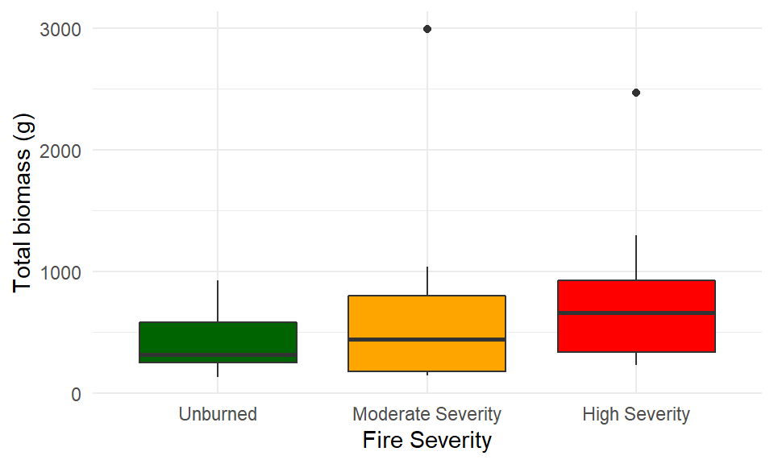

- Mean total site biomass increased with fire severity, but the differences between treatments was not significant (Kruskal-Wallis test, (chi square (2) = 2, p = 0.37, n = 9 for each).
- Results are the same using PHYLACINE and PanTHERIA body size data
- Outliers are sites that had a lot of ground squirrels

**Total biomass by species across the fire severity gradient:**

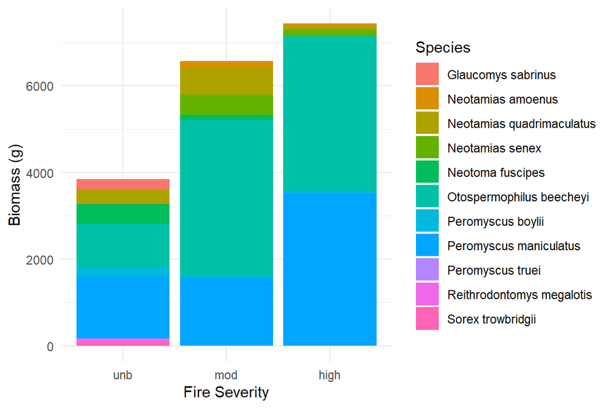

- Total biomass summed across sites for each severity, with the proportion contributed by each species.
- Increases in biomass were mainly driven by *P. maniculatus* and *O. beecheyi*.
- Strange that even though the mean biomass did not change between severities, the total biomass was much higher for mod and high severities (skewed by ground squirrel outliers)

#### Diet

**Abundance by feeding guild across the fire severity gradient:**

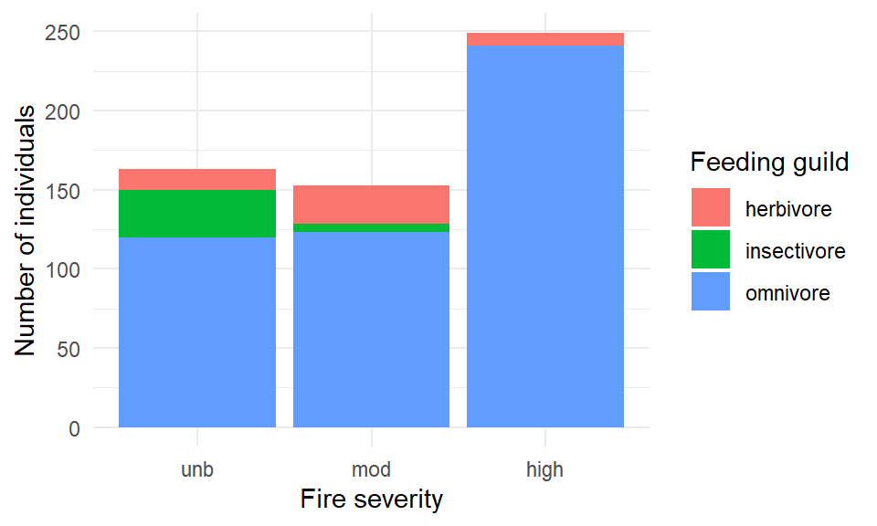

- All three treatments were dominated by generalist species.
- Categorical feeding guild (herbivore, omnivore, carnivore, insectivore) was not used in functional diversity calculations

**Community-wide daily food consumption for each diet item:**

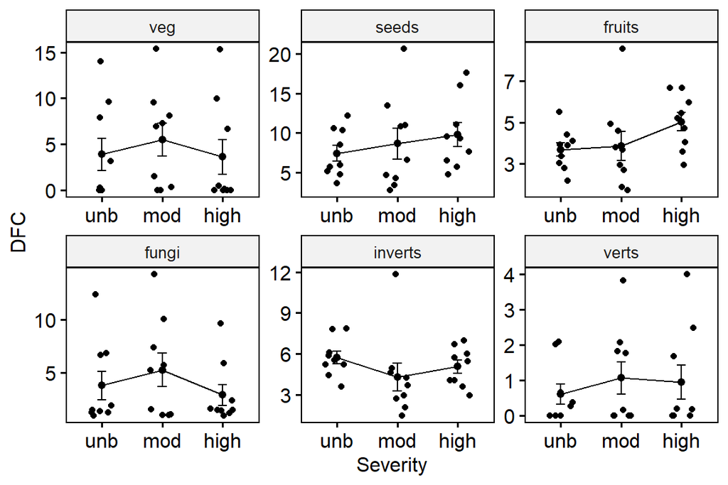

- DFC for each diet item did not vary across the fire severity gradient.
- Differences in the community-wide DFC (in grams/day, summed across individuals of species at each site) between treatments for each diet item were not significant (nonparametric one-way ANOVA-type multivariate test F(4.2, 50.5) = 2.47, p = 0.054).
- DFC scales allometrically with body mass and is equal to FMR/ME
- Biomass was calculated from field measurements

**Mosaic plot of community diet across fire severities:**

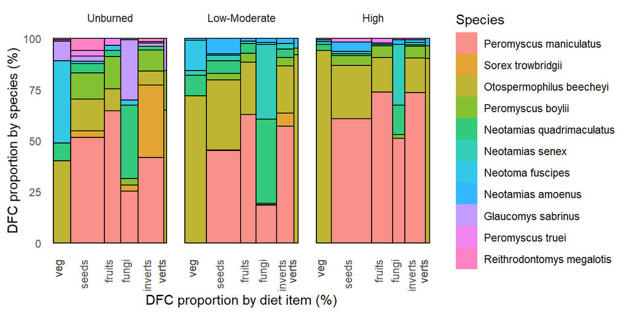

- Proportion of total daily food consumption (summed across sites) of each type of diet item by species for each severity. Although the overall proportion of DFC for each type of diet item remained consistent between treatments, the species consuming each diet item varied.
- DFC was calculated similarly to above

#### Foraging mode

**Abundance by foraging height across fire severity treatments:**

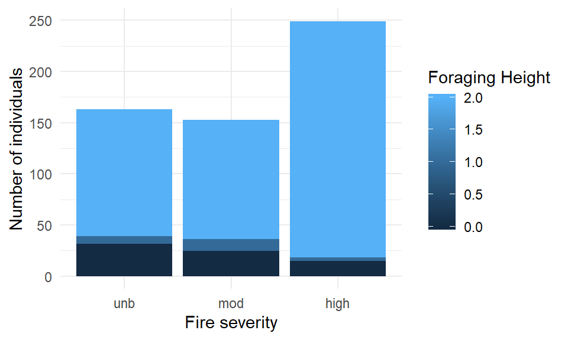

- All severities were dominated by scansorial species.
- Values:
  - 0 = fully terrestrial
  - 1 = scansorial - lower canopy
  - 2 = scansorial - upper canopy
  - 3 = fully arboreal (no representatives in our data)

**Abundance by degree of fossoriality across fire severity treatments:**

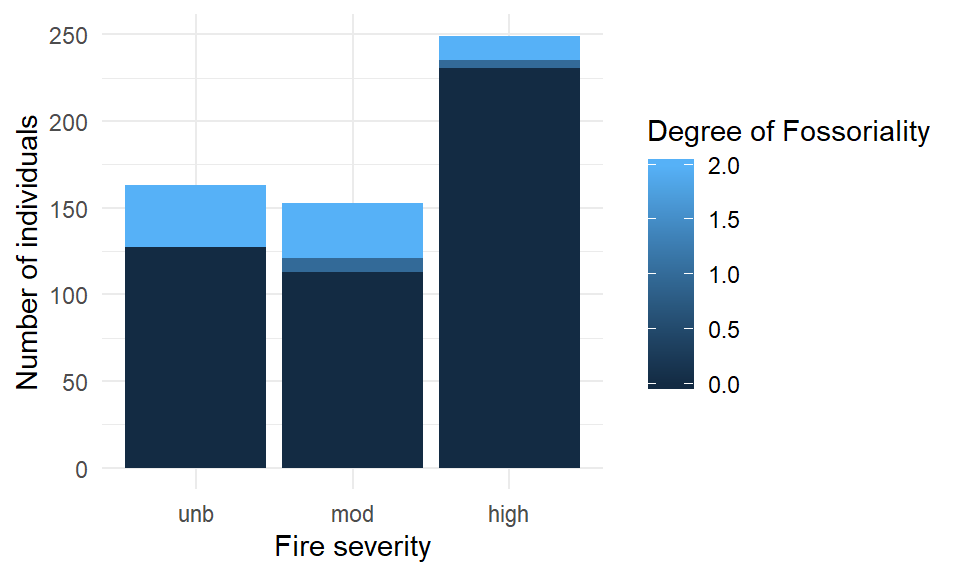

- All severities were dominated by non-fossorial species.
- Values:
  - 0 = non-fossorial
  - 1 = semi-fossorial (sometimes forages underground)
  - 2 = semi-fossorial (sometimes forages and caches food underground)
  - 3 = fully fossorial (no representatives in our data)

#### Activity time

**Abundance by activity time across fire severity treatments.**

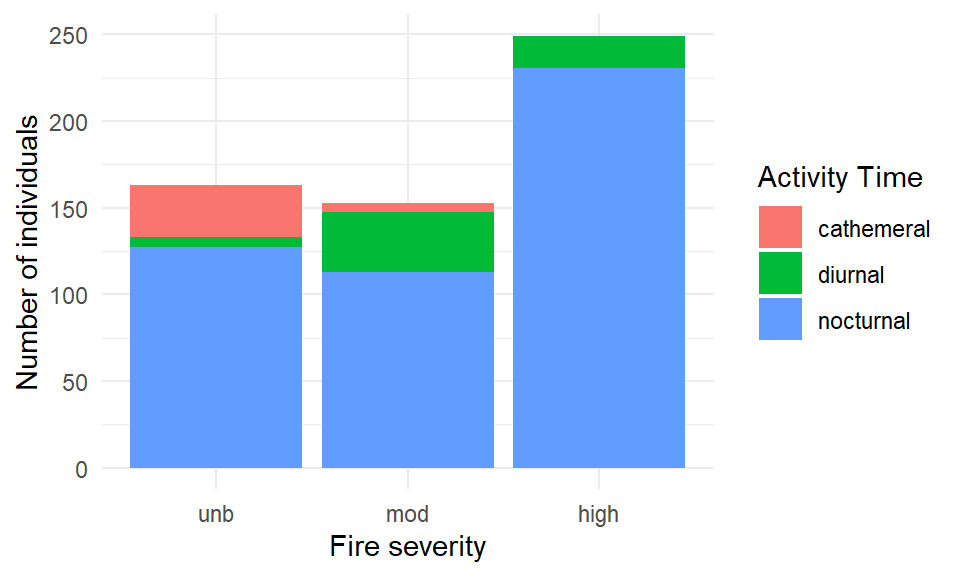

- All severities were dominated by nocturnal species.
- This may be misleading because traps were primarily open at night.

### Functional Diversity Indices

**Index calculation:**

1. Uses Gower dissimilarity matrix (can use ordered, categorical, and numerical variables)
   - integrates variable weights
2. Conducts PCA on the distance matrix and uses the resulting PC axes as ‘traits’ to compute FD indices
3. Calculates indices based on equations in (Laliberte & Legendre, 2010)

**Metrics:**

- Functional richness (FRic)
- Functional divergence (FDiv)
- Functional evenness (FEve)
- Functional dispersion (FDis)

**Functional traits included:**

- Body size
- Diet
  - Seeds
  - Fruits
  - Vegetation (other)
  - Fungi
  - Invertebrates
  - Vertebrates
- Foraging mode
  - Foraging height
  - Degree of fossoriality
- Colonization ability
  - Home range
  - Litter size
  - Annual litters
  - Longevity
  - Age at sexual maturity

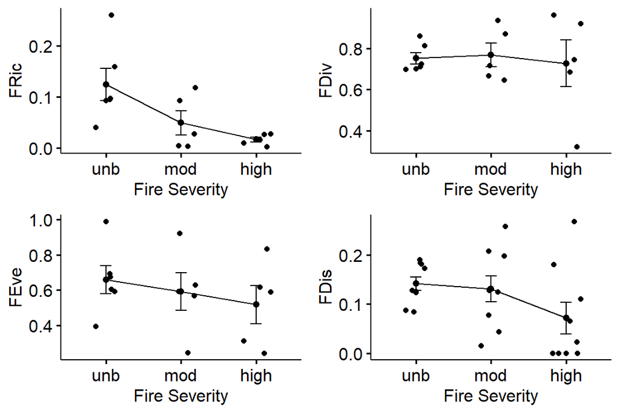